# Credit Card Fraud

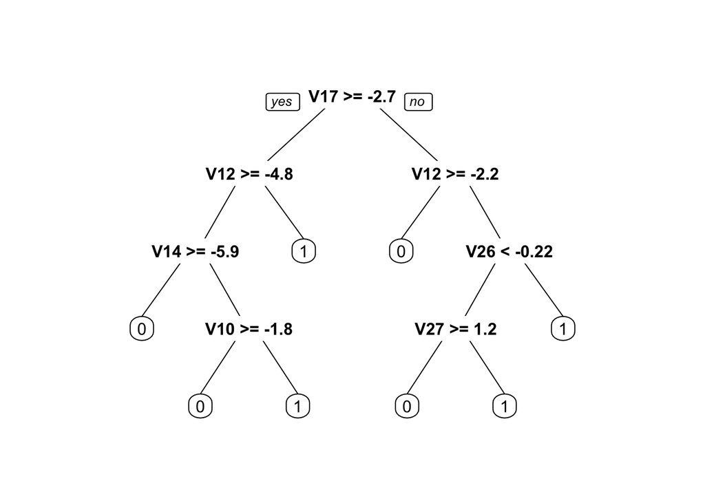

```r
tree.model <- rpart(Class ~ ., data = train.data, method = "class", minbucket = 20)
prp(tree.model)
```

```r
tree.predict <- predict(tree.model, test.data, type = "class")
confusionMatrix(test.data$Class, tree.predict)
```

```
## Confusion Matrix and Statistics
##
##           Reference
## Prediction     0     1
##          0 85323    12
##          1    34    74
##
##                Accuracy : 0.9995
##                  95% CI : (0.9993, 0.9996)
##     No Information Rate : 0.999
##     P-Value [Acc > NIR] : 1.637e-06
##
##                   Kappa : 0.7626
##  Mcnemar's Test P-Value : 0.00196
##
##             Sensitivity : 0.9996
##             Specificity : 0.8605
##          Pos Pred Value : 0.9999
##          Neg Pred Value : 0.6852
##              Prevalence : 0.9990
##          Detection Rate : 0.9986
##    Detection Prevalence : 0.9987
##       Balanced Accuracy : 0.9300
##
##        'Positive' Class : 0
##
```

6. PRUNING ##It gives us a much simpler model for presentation purpose. But as compared to the regression tree, we cannot expect to have a higher accuracy on prune tree, but due to presentability of data, we will use it.

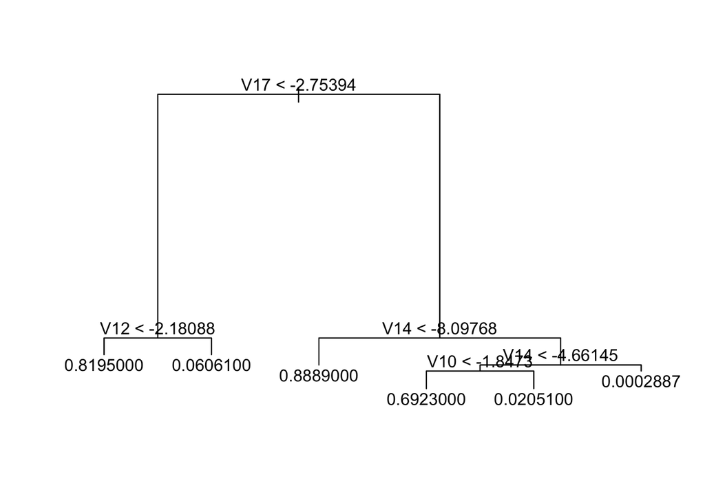

```r
cv.credit <- cv.tree(tree.credit)
prune.credit <- prune.tree(tree.credit, best=5)
plot(prune.credit); text(prune.credit,pretty=0)
```

RESULTS (via Logistic regression):

“Our best model was LOGISTIC REGRESSION”

1- YES, it is possible to achieve 100% accuracy for Fraud detection. But when we do that, the number of Type 2 errors increase dramatically. This model rigorously classifies CLEAN transactions as FRAUD.

2- We have to further work on the model by relaxing the data-model AT THE COST of lowering the fraud detection accuracy. The result is that our type 1 error dramatically reduces but it also reduces the ability of the model to capture all fraud-transactions.

3- The o-efficient of Amount was less, which could be due to the fact that it was not transformed. It may already have correlations.

4- The most useful specificity is the Threshold cutoff probability. In an actual business, the important part is to minimize type-2 errors (rejecting Clean transactions), while correctly classifying all fraud. It is a trade off struck between the two. This probability is threshold cutoff probability.

5- Accuracy of this model is max atp =0.4785 hence the standard cut-off rate of 0.5 has no more use here, than that of a reference point.

Recommendation:

1- We need a much higher data set for fraud transactions, with more data and with more time, it is possible to achieve 100% correct detection of fraud transactions.

Lesson learned:

1- There is no fixed one-model when trying to solve the business problem by machine-learning.

2- You need to try multiple models and trust the statistics to teach the machine itself.

3- Within each model, there are several tuning factors which have significant impact, but they require careful use, for example, set.seed function is a random number generator who’s values can change the outcome accuracy.